# How Bus travel time is affected by multiple factors

## Introduction:

**This visual data** story explores factors that influence 195 bus travel times based on a data set of logged bus journeys. The data set includes information such as travel time, number of stops,delay reasons and the time and day of each trip occurred.

**The aim of** this is investigate how bus travel time changes depending on different conditions,including delay cause,time of day, and day of the week. By transforming the time stamp data into a usable variable by using the *lubricate* package, it was possible to examine patterns across both hourly and weekly cycles.

**These visualizations are** used to explore these relationships and identify when and why bus travel times tend to increase and when is the best time to catch the bus.

## Graph one:

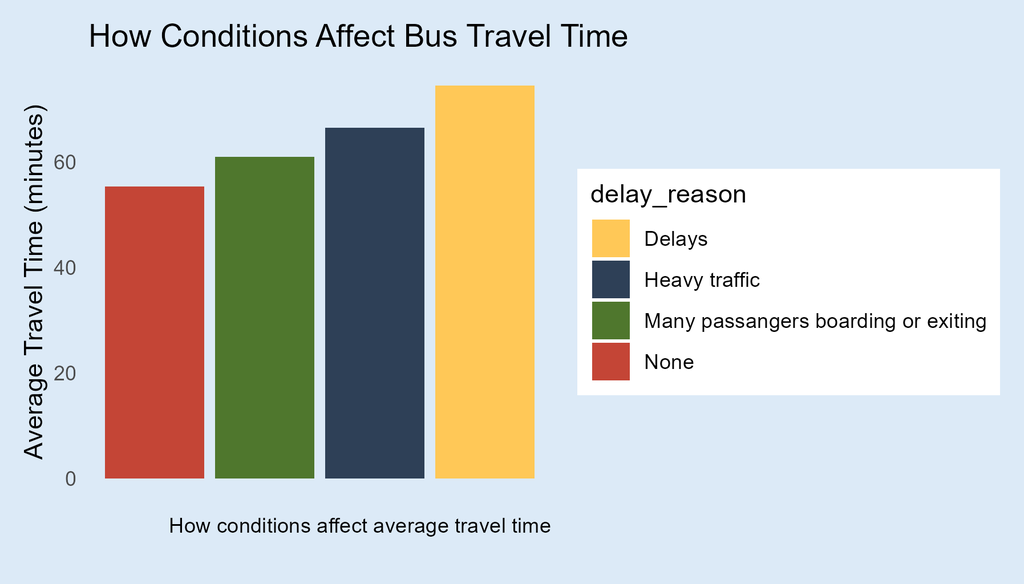

Plot that shows how diffrent conditions and which affects average bus travel time the most

**Text for explanation**: This visualization tells a story about how different conditions can affect the experience of traveling home by bus. The data suggests that passengers that suffered from heavy traffic are more likely to arrive home later compared to those travelling with no conditions. This is likely caused by people rushing out of the city as soon as they possibly can.

**One less major factor** is bus passengers, and by that, I mean the amount of people boarding and exiting the bus. This could last from 10-15 seconds every time a person boards or leaves the bus, however it dose add up over time which is why it’s still slightly greater then having none of these conditions.

However this may not be the only factor at play here as the time and day of the week may also play a vital impact. And as a result, commuters like you are may have less free time in the evening because commuters spend a longer time traveling. Don’t worry though, because visualization two should help clarify this even more.

## Graph 2:

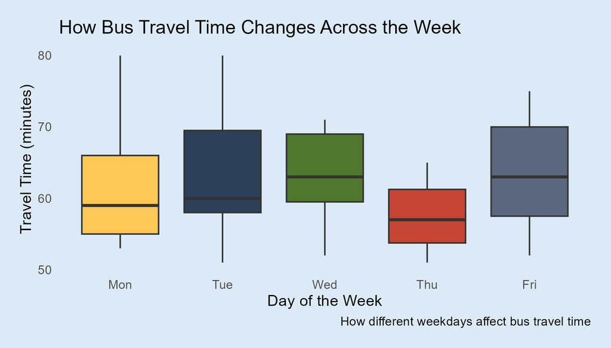

Boxplot showing bus travel time across different weekdays, highlighting variation and spread in travel times with some days showing higher delays than others

**Text for explanation**: This visualization shows how bus travel time changes depending on the day of the week. The data suggests that travel times are generally longer during the middle and end of the working week, especially on Wednesday and Friday. This is likely because more people are travelling during these days for work, study, and other commitments, leading to busier roads and slower journeys.

**Another noticeable pattern** is that Thursday appears to have the shortest and most consistent travel times overall. When compared to the other weekdays, the box plot for Thursday is positioned slightly lower, meaning passengers were more likely to get home faster. This could suggest there was less traffic congestion or fewer delays on that day. So if you work at the city during Thursday, lucky you!

**Looking back at** the previous visualization, we can see how the conditions that affect the time the most is delays,followed up by heavy traffic then lastly number of passengers. From this visualization we see that travel times were less consistent on Tuesday and Friday which if we pair it up with our previous understanding, suggest that these days are more likely to have the most passengers, possible delays and most amount of people.

**The day of** the week may not be the only factor affecting travel time. The time of day could also play a major role, as buses travelling during peak commuting hours are more likely to encounter traffic and delays. Because of this, commuters may spend more time travelling home and have less free time in the evening. The next visualization explores this relationship further by looking at how travel time changes throughout the day.

## Graph 3:

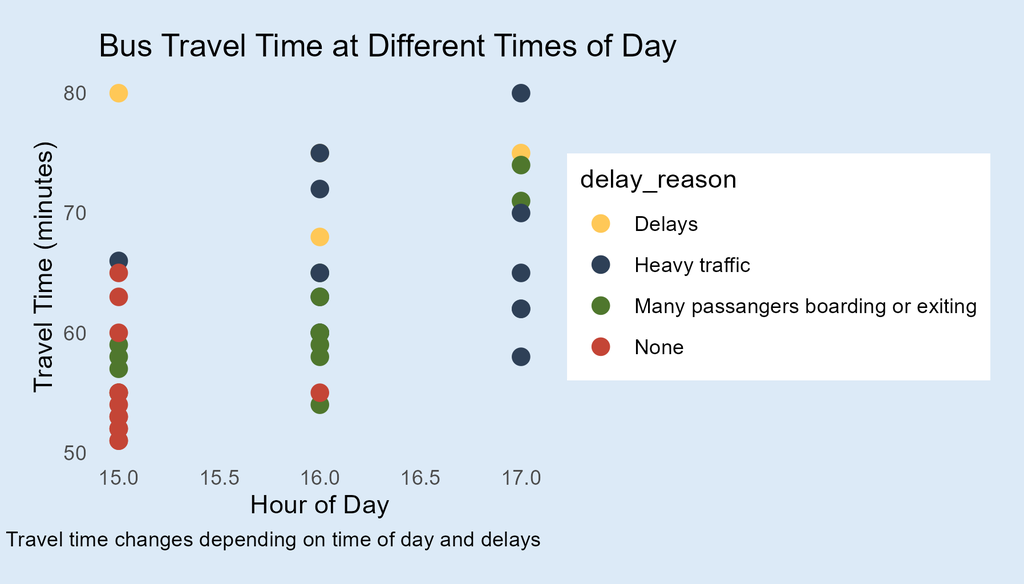

Scatter plot showing bus travel time against hour of day, with points coloured by delay reason to show how delays vary across different times

**Text for explanation**: This visualization shows how bus travel time changes depending on the time of day and the type of delay experienced. Each point represents an individual bus trip, while the different colours represent the reason for the delay. From the graph, we can see that travel times generally increase later in the afternoon, especially around 5pm, which is likely caused by peak-hour traffic as commuters travel home from work or study.

**Another interesting trend** is that delays unrelated to traffic also appear to increase travel time noticeably. Trips categorized as “Delays” reached some of the highest overall travel times in the data set, including one trip close to 80 minutes at 3pm. This supports the findings from the previous visualizations, where delays were shown to have the greatest impact on average travel time overall despite being the reason that occurs way less compared to the others.

**The number of passengers** boarding and exiting the bus also appears to slightly increase travel times, although not as much as heavy traffic or delays. These trips generally don’t add much time to the bus though compared to road congestion or unexpected delays so you lucky if you get these conditions because we all know your most likely to suffer from heavy traffic because Auckland roads suck so much.

## Conclusion and general reccomendations:

**As for you** Auckland council, although the 195 bus has a separate route compared to other buses, I bet the common denominator with bus travel time across Auckland is due to heavy traffic and delays when they happen, which is very rarely to occur. My recommendation is to try and get less cars on the roads by improving the public transport system by including more bus lanes during peaks hours so buses can avoid more of the heavy traffic, better train systems so people take the train instead of the bus or car which furthermore reduces the condition that Many passengers boarding or exiting places on bus travel times.

## **Thank you and Goodbye!**

[figure not shown]

A waving goodbye